# Coursework Report

*N* removed NAs: 3

*N* removed typo: 1

*N* removed <18: 30

*N* total clean: 116

| Group | *N* | *M*<sub>age</sub> | *M*<sub>rating</sub> |
| --- | --- | --- | --- |
| Control | 56 | 21.0 | 6.86 |
| Experim | 60 | 21.2 | 5.46 |

**Main analysis results**

*t*(114) = 9.08, *p* < .001

[interactive chart not shown]

[figure not shown]

[interactive chart not shown]

# Coursework Report

Analysing Data, Spring 2020

# Method

## Participants

```
## # A tibble: 2 x 6
##   group            n mean_age_years sd_age_years min_age_years max_age_years
##   <fct>        <int>          <dbl>        <dbl>         <dbl>         <dbl>
## 1 control         56           21.0         2.30            18            28
## 2 experimental    60           21.2         2.36            18            27
```

## Design

The following study was an attempt to replicate Elliot et al.’s (2010) red study and therefore was designed to see if a red effect on men has influence on their attractiveness and female’s desirability. Similarily to the original experiment, this study used a between subject’s design which consisted of one control condition and an experimental condition. Participants were allocated to either one of the conditions. The control condition presented an averagely attractive man with a white frame, and the experimental condition showed an averagely attractive man with a red frame around his picture. With this our female participants were given questions and asked to rate their opinion of attractivenss on a 1-9 Likert Scale, where 1 represents the lowest and 9 the highest rating. The colour variable is identified as our catagorical variable and our predictor, with two levels, as mentioned previously : white and red. Whilst the attractiveness rating is our continuous variable and also represents our outcome. Our null hypothesis questions if the mean of the control group is equal to the mean of the experimental group, therefore our alternative hypothesis is the opposite. In this study we will run a t-test statistical analysis to test this.

# Results

This study aimed to investigate whether colour influences attractiveness of men. The data we analysed revealed a difference between the means of ratings for both conditions: control mean (*M* = 6.86) and Experimental mean (*M* = 5.46). This finding is also evident from figure 2 below , which nicely represents a means plot of our results. We ran a *t*-test, to test our null hypothesis and distinguish the difference in mean between the two groups (*M*<sub>diff</sub> = 1.4). From this, the *t*-test showed a high *t*-statistic (9.08) and a very small *P*-value (*p* = 0) which suggests that we reject the null hypothesis. Precicely, this is therefore suggesting that the means of both conditions are different and are different not by chance. This reveals that our control group rates white more attractive than the experimental group rates red. However, this is significant because our findings show a reverse result to Elliot et al.’s original study.

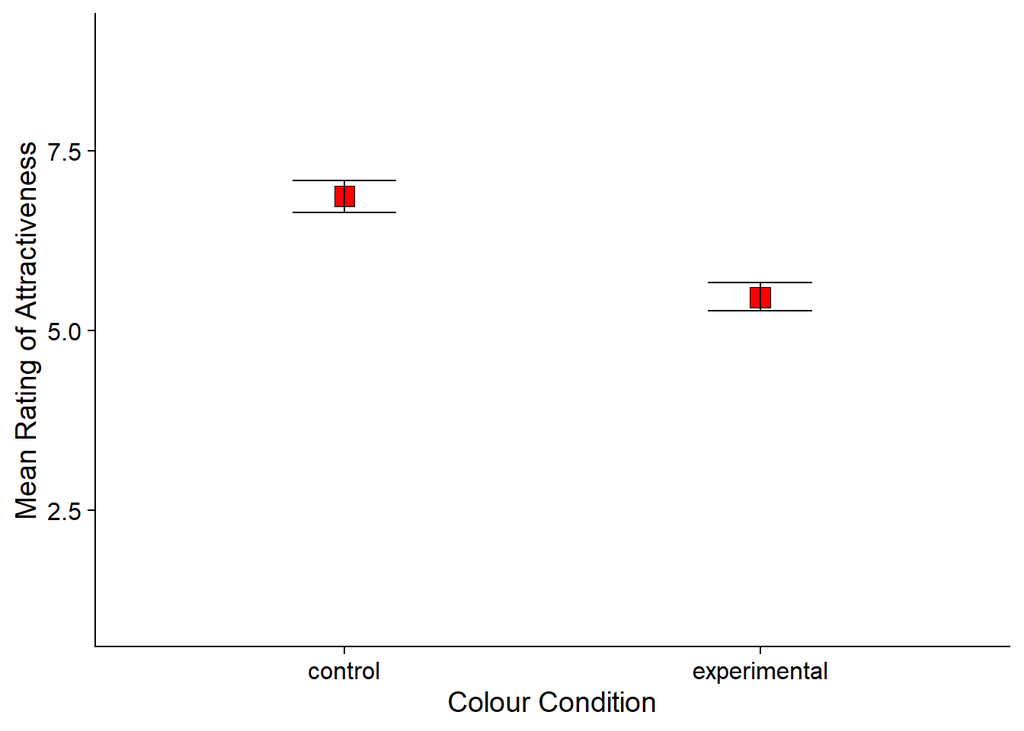

# Discussion

When we think of the colour red, some think of anger or danger and some think of love and affection. Colours have an influence on aspects of our lives, especially our moods and feelings. It has become common now that women in red makes them more attractive and sexually desirable to men. Whether now that is a stereotype or actually real, over time red has become more and more associated with this. We can even link the intense colour to be an aphrodisiac, for example red lingerie or lipstick and dresses. Researchers have become more interested with this and ask the question whether this can be the other way around too: questioning whether men in red are ranked higher in attractiveness by women.

The present research was an attempted replication of Elliot et al.’s (2010) hypothesis that red enhances women’s attractiveness rating of men (Elliot, et al., 2010). According to their results, women tend to perceive men with a red background or associated with red, as more attractive, higher in status and more sexually desirable (Hesslinger, Goldbach, & Carbon, 2015). Yet, the results of our study do not provide strong evidence that red influences women’s attractiveness rating of men. Our findings show that the control group (white frame) rate men more attractive than woman in the experimental group (red frame) do. This does not suggest that red has not had any influence on their ratings and has no effect, as this we cannot be sure of. Though it reveals that Elliot et al.’s (2010) study is not reliable as when we replicate the experiment, we do not get the same results. Our findings from the *t*-test statistical analysis propose that we adopt the alternative hypothesis and reject the null hypothesis. This suggests to us that our two condition groups have such a large difference in results that it is unlikely to have occurred by chance.

Hesslinger et al (2015) also re-examined the research question and found no successful correlation between men in a red background and women’s rating of attractiveness and perceived status. This emphasizes that there is no supporting evidence that red has an influence on attractiveness other than the original study. Consequently, there has been evidence for the research question which asks whether wearing red influences men’s perceived attractiveness on women. In Elliot and Niesta’s (2008) study, they found evidence for this. (Elliot & Niesta , 2008). Therefore, perhaps there is a red effect on women, though we do not have enough evidence to deduce this for men. However, most replicated studies designed their experiments, so that the independent variable (colour) is the background of the picture, for example, again, Hessigner et al. (2015) conducted their experiment with a coloured background and found no influence of red on attractiveness rating. Nevertheless, the original study did have 3 experiments (experiment 4, experiment 5a and experiment 6a) in which they presented a man in a coloured shirt. Therefore, perhaps having the target wearing a coloured apparel rather than a background could have made a difference in our results.

Moreover, a strength in our experiment is that we adopted a design which didn’t use different photos of an averagely attractive man, or different styles of clothing. Adopting this approach is constructive as attractiveness is subjective and therefore, sometimes personal opinions influence judgements. This could give more insight into whether it is actually the colour which influences our results or personal preferences and we can control that it is our manipulations on the colour that influences the results. In addition, we decided to use a between-subjects design to carry out our study. At first glance, this design is effective as it is less time consuming and enables us to have a larger sample size. However, sometimes many participants can create some implications. We can see this clearly from our experiment; originally, we had 150 participants but had to remove 34 participants for invalid data or unethical data. This removes some participants and potential data which could’ve helped us answer our research question more accurately. In most studies; Peperkoorn et al (2016), Hesslinger et al (2015), Elliot et al. (2008) & (2010), they conducted the experiment multiple times for certainty and accuracy. In the present study, we had a control condition which was helpful, though, we only conducted the experiment once for both conditions. It might have been better to conduct them more than once to get more accurate results and reduce the chance of the results being out of chance. Though, another strength in our experiment was that we used white as a control group colour. This is effective because white doesn’t attract as much attention as red does, which can help indicate if the colour red is actually attractive.

# References

Elliot, A. J., & Niesta , D. (2008). Romantic Red: Red Enhances Men’s Attraction to Women. Journal of Personality and Social Psychology.

Elliot, A. J., Kayser, D. N., Greitemeyer, T., Lichtenfeld, S., Gramzow, R. H., & Maier, M. A. (2010). Red, Rank, and Romance in Women Viewing Men. Journal of Experimental Psychology.

Hesslinger, V. M., Goldbach, L., & Carbon, C.-C. (2015). Men in red: A reexamination of the red-attractiveness effect.

Peperkoorn, L. S., Roberts, C. S., & Pollet, T. V. (2016). Revisiting the Red Effect on Attractiveness and sexual Receptivity: No Effect of the Color Red on Human Mate Preferences. Evolutionary Psychology.